[figure not shown]

# Combiner plusieurs graphiques

Ce chapitre est évoqué dans le webin-R #14 (exemples de graphiques avancés - 2) sur [YouTube](https://youtu.be/iJT46MGSQA8).

Vous savez réaliser des graphiques avec **ggplot2** ? Il est très facile de combiner plusieurs graphiques en un seul.

Commençons par créer quelques graphiques avec `ggplot2`.

```r
library(ggplot2)
p1 <- ggplot(mtcars, aes(wt, mpg)) +
  geom_point()
p2 <- ggplot(mtcars, aes(factor(cyl))) +
  geom_bar()
p3 <- ggplot(mtcars, aes(factor(cyl), mpg)) +
  geom_violin()
p4 <- ggplot(mtcars, aes(factor(cyl), mpg)) +
  geom_boxplot()
```

## plot_grid (cowplot)

L’extension `cowplot` propose une fonction `plot_grid`. Son usage est expliqué en détail dans les vignettes dédiées inclues avec l’extension : https://wilkelab.org/cowplot/.

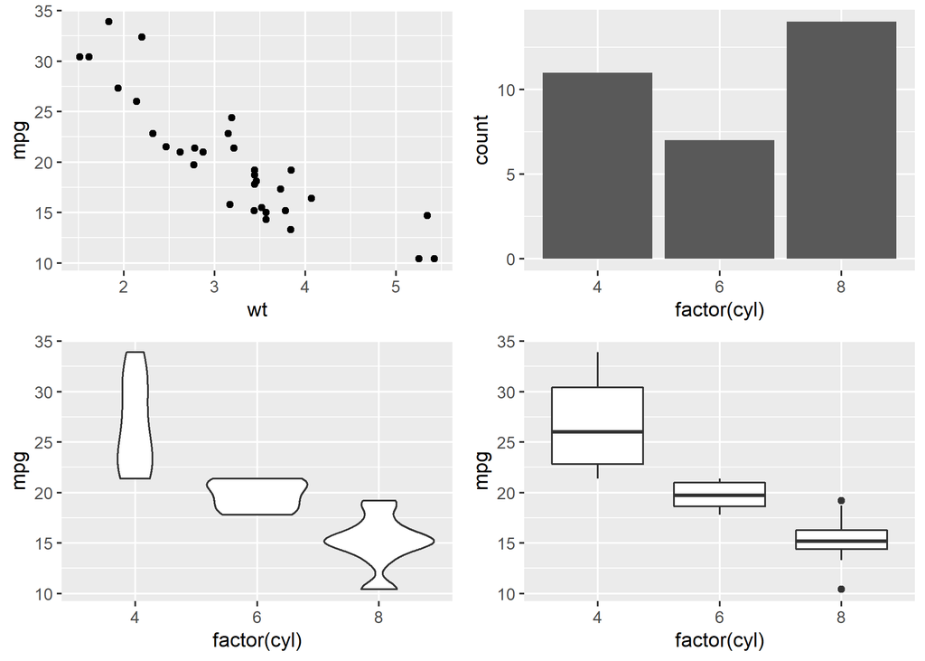

```r
library(cowplot)
# simple grid
plot_grid(p1, p2, p3, p4)
```

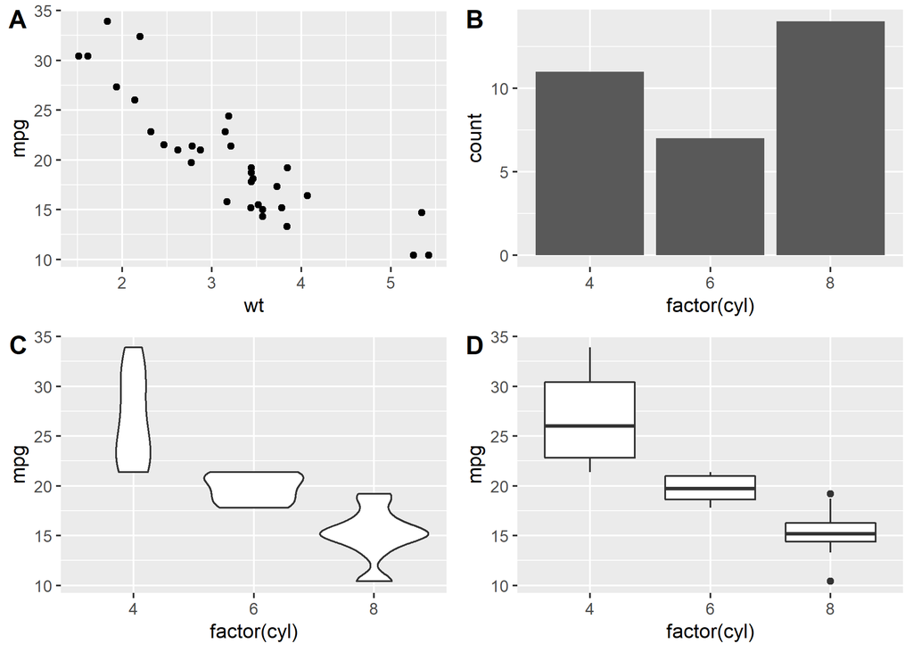

```r
# simple grid with labels and aligned plots
plot_grid(p1, p2, p3, p4, labels = c("A", "B", "C", "D"), align = "hv")
```

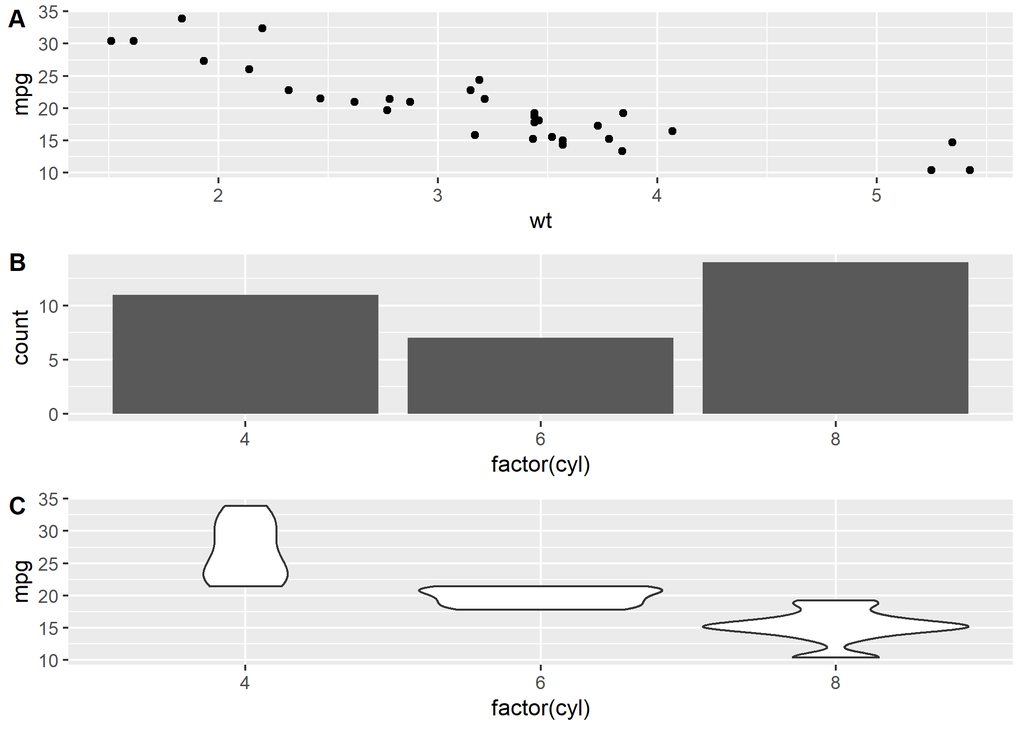

```r
# manually setting the number of rows, auto-generate upper-case labels
plot_grid(p1, p2, p3, nrow = 3, labels = "AUTO", label_size = 12, align = "v")
```

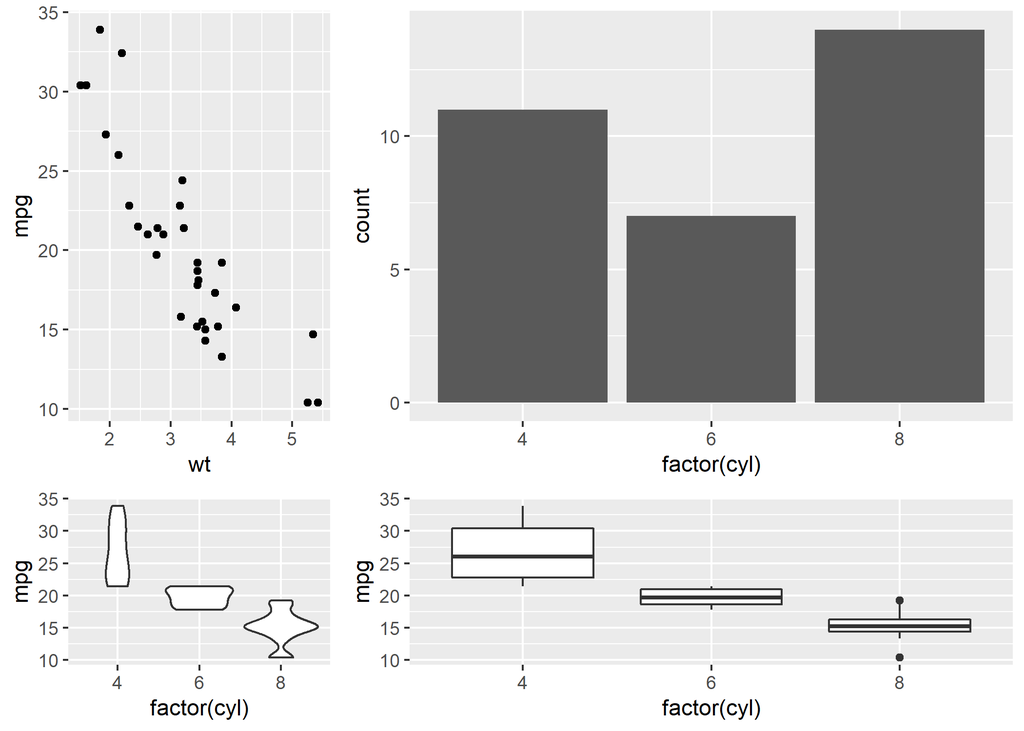

```r
# making rows and columns of different widths/heights
plot_grid(p1, p2, p3, p4, align = "hv", rel_heights = c(2, 1), rel_widths = c(1, 2))
```

On notera en passant que le chargement de `cowplot` modifie le style par défaut des graphiques `ggplot2`. Voir https://cran.r-project.org/web/packages/cowplot/vignettes/introduction.html.

## patchwork

Citons également l’extension `patchwork`, disponible sur GitHub (https://github.com/thomasp85/patchwork) qui propose une syntaxe un petit peu différente, par addition de graphiques.

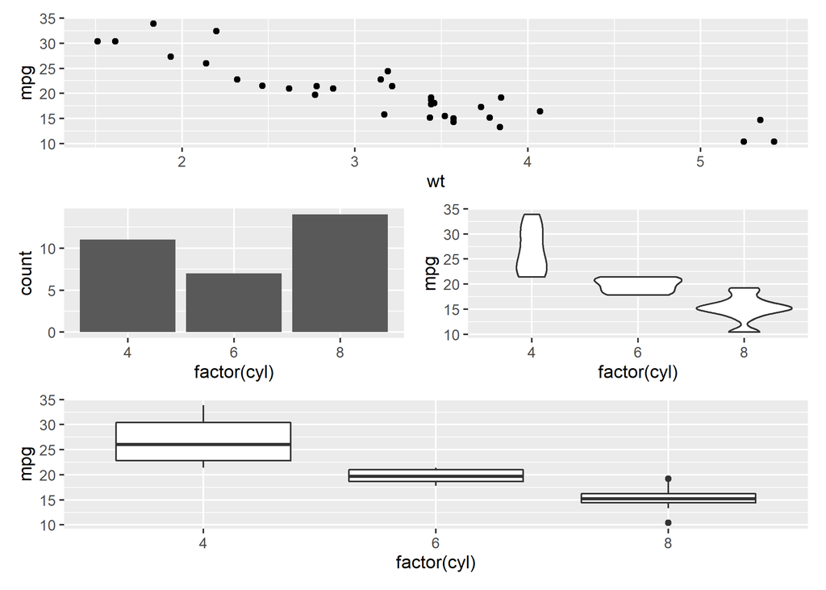

```r
library(patchwork)
p1 + (p2 + p3) + p4 + plot_layout(ncol = 1)
```

## multiplot (JLutils)

Dans son ouvrage *Cookbook for R*, Winston Chang propose une fonction `multiplot` pour combiner plusieurs graphiques[^1]

L’extension `JLutils` disponible sur [GitHub](https://github.com/larmarange/JLutils) propose une version améliorée de cette fonction.

Pour installer `JLutils` si non disponible sur votre PC, copier/coller le code ci-dessous.

```r
if (!require(devtools)) {
  install.packages("devtools")
  library(devtools)
}
install_github("larmarange/JLutils")
```

Parce que quelques exemples valent mieux qu’un long discours.

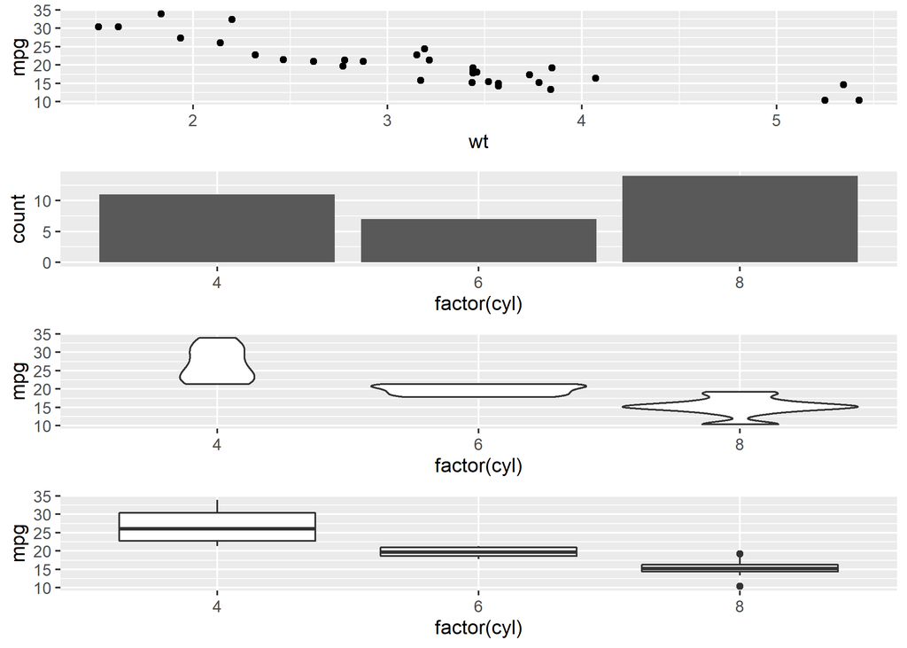

```r
library(JLutils)
multiplot(p1, p2, p3, p4)
```

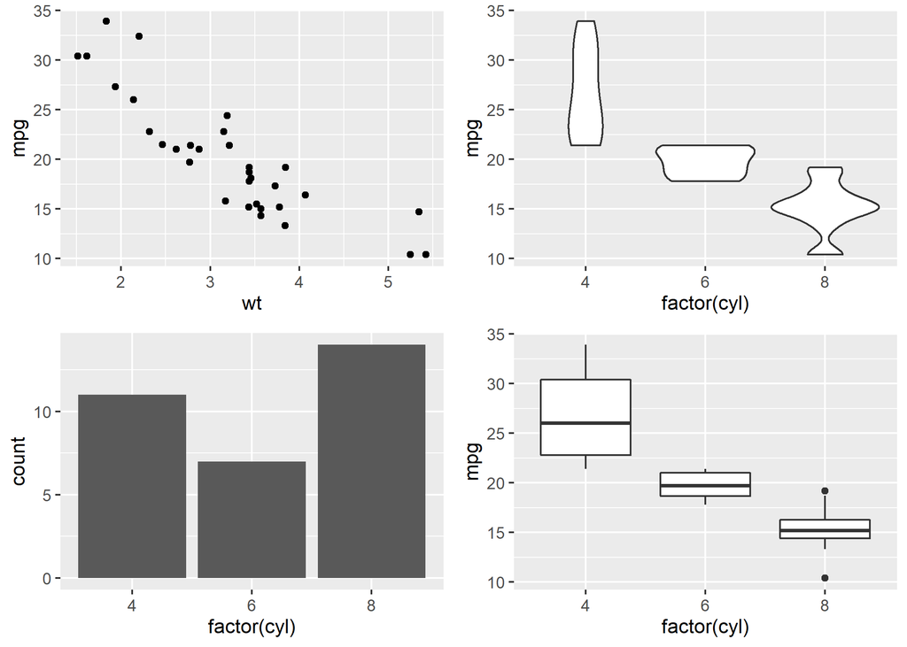

```r
multiplot(p1, p2, p3, p4, cols = 2)
```

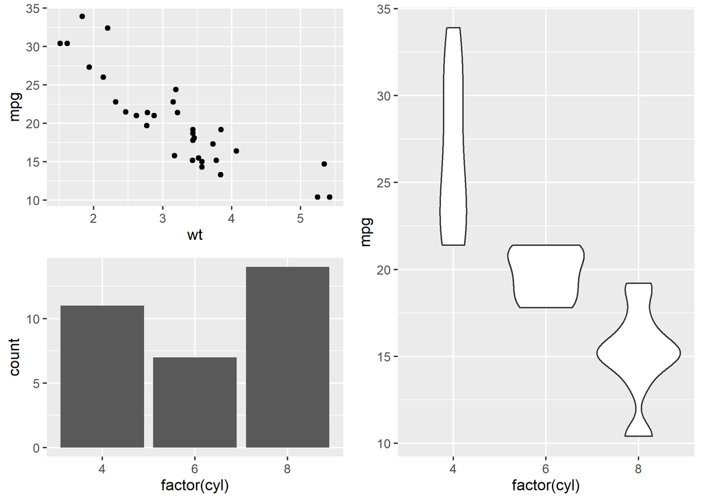

```r
multiplot(p1, p2, p3, layout = matrix(c(1, 2, 3, 3), nrow = 2))
```

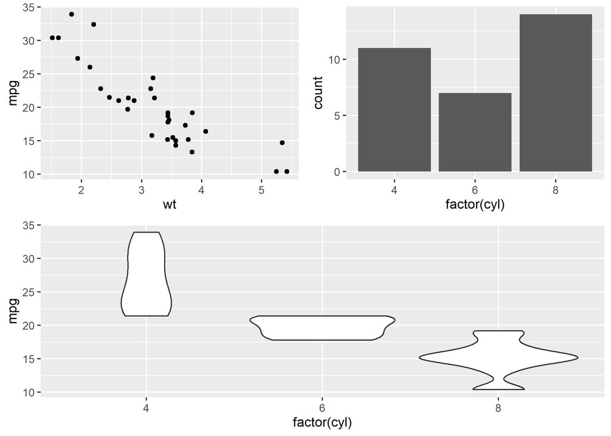

```r
multiplot(p1, p2, p3, layout = matrix(c(1, 2, 3, 3), nrow = 2, byrow = TRUE))
```

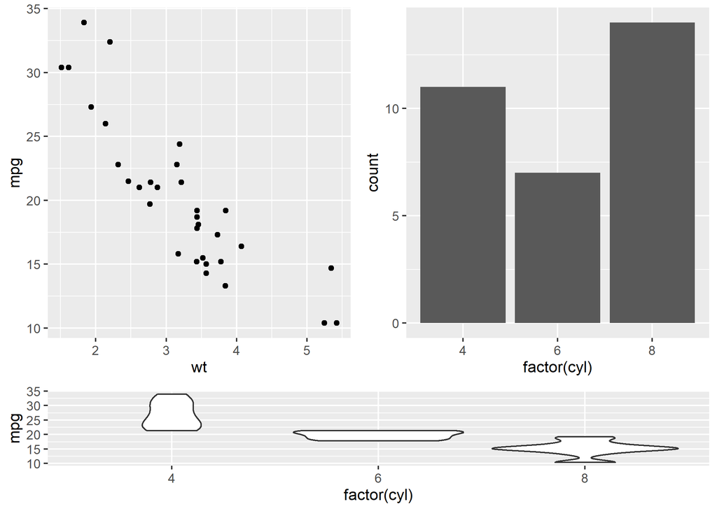

```r
multiplot(p1, p2, p3, layout = matrix(c(1, 2, 3, 3), nrow = 2, byrow = TRUE), heights = c(3, 1))
```

## Légende partagée entre plusieurs graphiques

`JLutils` et `cowplot` fournissent tous deux une fonction `get_legend` permettant d’extraire la légende d’un graphique puis de l’utiliser avec `multiplot` ou `plot_grid`.

Créons quelques graphiques.

```r
dsamp <- diamonds[sample(nrow(diamonds), 1000), ]
p1 <- qplot(carat, price, data = dsamp, colour = clarity) +
  theme(plot.margin = unit(c(6, 0, 6, 0), "pt"))
p2 <- qplot(depth, price, data = dsamp, colour = clarity) +
  theme(plot.margin = unit(c(6, 0, 6, 0), "pt")) + ylab("")
p3 <- qplot(color, price, data = dsamp, colour = clarity) +
  theme(plot.margin = unit(c(6, 0, 6, 0), "pt")) + ylab("")
```

Récupérons la légende du premier graphique graphique puis supprimons là dans les trois graphiques.

```r
leg <- get_legend(p1)
p1 <- p1 + theme(legend.position = "none")
p2 <- p2 + theme(legend.position = "none")
p3 <- p3 + theme(legend.position = "none")
```

Combinons le tout.

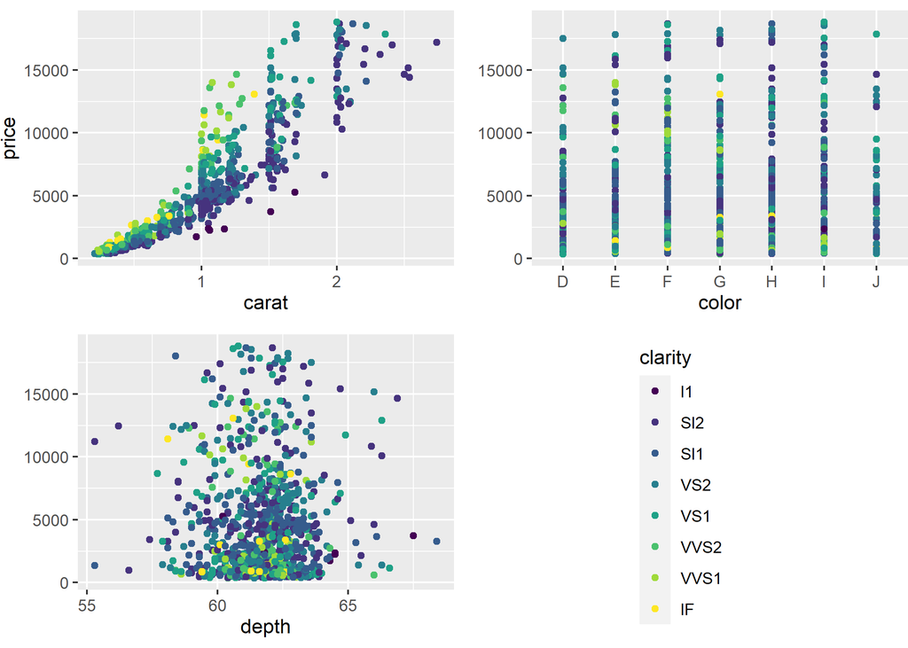

```r
multiplot(p1, p2, p3, leg, cols = 2)
```

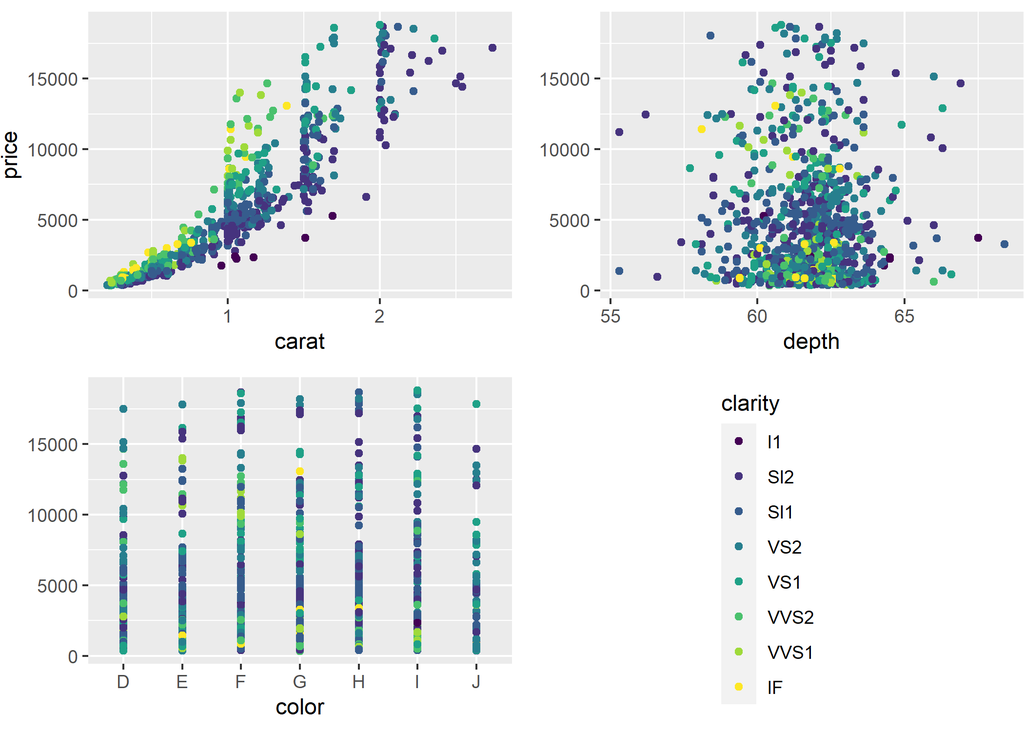

```r
plot_grid(p1, p2, p3, leg, ncol = 2)
```

Enfin, citons également la fonction `grid_arrange_shared_legend` de l’extension `lemon`[^2].

[^1]: Voir http://www.cookbook-r.com/Graphs/Multiple_graphs_on_one_page_(ggplot2)/.
[^2]: `lemon` fournit également diverses fonctions pour manipuler des graphiques `ggplot2`, comme par exemple la possibilité de répéter les axes quand on utilise des facettes.